# lab2

```python
import matplotlib.pyplot as plt
import pandas as pd
```

1. The bar plot of the penguins dataset shows the mean body mass of the three penguin species (Adelie, Chinstrap, and Gentoo) by sex (male and female).

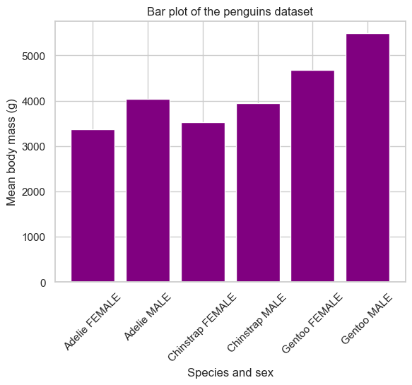

```python
# Load the penguins dataset
penguins = pd.read_csv("https://raw.githubusercontent.com/mwaskom/seaborn-data/master/penguins.csv")

# Create a bar plot of the mean body mass by species and sex
grouped = penguins.groupby(["species", "sex"])["body_mass_g"].mean().reset_index()
plt.bar(x=grouped["species"] + " " + grouped["sex"], height=grouped["body_mass_g"], color = "purple")
plt.xlabel("Species and sex")
plt.ylabel("Mean body mass (g)")
plt.title("Bar plot of the penguins dataset")
# Rotate x-labels on the x-axis by 45 degrees
plt.xticks(rotation=45)
plt.show()
```

The plot reveals that the Gentoo penguins have the highest mean body mass, followed by the Chinstrap and then the Adelie. It also shows that the male penguins are generally heavier than the female penguins across all species.

1. The pie chart of the tips dataset shows the percentage of tips by day from Thursday to Sunday. The data source for this plot is the [tips dataset] from the seaborn library.

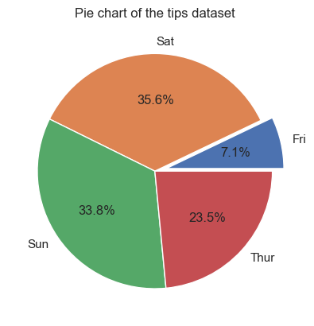

```python
# Load the tips dataset
tips = pd.read_csv("https://raw.githubusercontent.com/mwaskom/seaborn-data/master/tips.csv")

# Create a pie chart of the percentage of tips by day
tips_by_day = tips.groupby("day")["tip"].sum()
plt.pie(tips_by_day, labels=tips_by_day.index, autopct="%1.1f%%", explode=[0.1, 0, 0, 0])
plt.title("Pie chart of the tips dataset")
plt.show()
```

The plot uses different colors and labels to indicate the proportion of tips for each day, with the percentage shown in each slice. The plot also highlights the Friday slice by exploding it from the rest of the pie. The plot reveals that the tips are highest on Saturday (35.6%), followed by Sunday (33.8%), Thursday (23.5%), and Friday(7.1%).

1. The violin plot of the mpg dataset shows the distribution of horsepower by origin and cylinders, only for 4 and 6 cylinders. The plot uses different colors and shapes to indicate the origin and the number of cylinders for each car, with the quartiles shown inside the violins. The data source for this plot is the mpg dataset from the seaborn library.

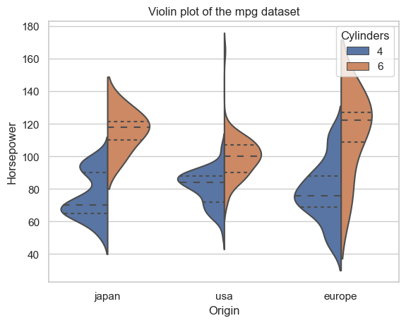

```python
import seaborn as sns
import matplotlib.pyplot as plt

# Load the mpg dataset
mpg = sns.load_dataset("mpg")

# Filter the data to only include 4 and 6 cylinders
mpg_filtered = mpg[mpg["cylinders"].isin([4, 6])]

# Create a violin plot of the distribution of horsepower by origin and cylinders
sns.violinplot(x="origin", y="horsepower", hue="cylinders", data=mpg_filtered, split=True, inner="quartile")
plt.xlabel("Origin")
plt.ylabel("Horsepower")
plt.title("Violin plot of the mpg dataset")
plt.legend(title="Cylinders")
plt.show()
```

1. The swarm plot of the iris dataset shows the distribution of petal length by species. The data source for this plot is the iris dataset from the seaborn library.

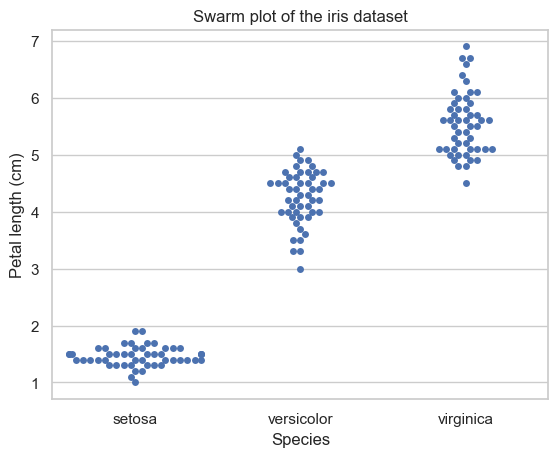

```python
# Load the iris dataset
iris = sns.load_dataset("iris")

# Create a swarm plot of petal length by species
sns.swarmplot(x="species", y="petal_length", data=iris)
plt.xlabel("Species")
plt.ylabel("Petal length (cm)")
plt.title("Swarm plot of the iris dataset")
plt.show()
```